# Lecture 4: Data Visualization in R (maps)

September, 2015

## Today

Saving scripts in R

Generate lecture code examples

Maps in `ggplot2`

Exercises (maps & data manipulation)

## Code from lectures

Use the `knitr` package

```r
# install.packages("knitr")
library("knitr")
purl("https://raw.githubusercontent.com/sebastianbarfort/sds/gh-pages/_slides/lecture3.Rmd")
```

## Making maps

There are many ways to make maps in R

1. **easy**: use an existing package
2. **hard**: learn how to work with shapefiles (we don't have time for this today, but I strongly recommend reading [these notes](https://github.com/Robinlovelace/Creating-maps-in-R/raw/master/intro-spatial-rl.pdf) on the topic)

Today focus is on 1.

## Map packages

There are many useful packages for making maps in R

- `maps`: all kinds of maps
- `ggcounty`: generate United States county maps
- `ggmap`: extends `ggplot2` for maps
- `mapDK`: maps of Denmark

## Marijuana prices

Let's return to our marijuana price data

```r
library("readr")
df = read_csv("https://raw.githubusercontent.com/sebastianbarfort/sds/master/data/marijuana-street-price-clean.csv")
```

Generate yearly state level means

```r
library("lubridate")
library("dplyr")
df$year = year(df$date)

df = df %>%
  group_by(State, year) %>%
  summarise(
    m.price = mean(HighQ, na.rm = TRUE)
  ) %>%
  mutate(
    region = tolower(State)
  )
```

## `maps`

The `maps` package has geographic information on all U.S states

```r
library("maps")
library("ggplot2")
us.states = map_data("state")
head(us.states)
```

```
##        long      lat group order  region subregion
## 1 -87.46201 30.38968     1     1 alabama      <NA>
## 2 -87.48493 30.37249     1     2 alabama      <NA>
## 3 -87.52503 30.37249     1     3 alabama      <NA>
## 4 -87.53076 30.33239     1     4 alabama      <NA>
## 5 -87.57087 30.32665     1     5 alabama      <NA>
## 6 -87.58806 30.32665     1     6 alabama      <NA>
```

Merge the data

```r
df.merge = left_join(df, us.states)
```

## Plotting with `ggplot2`

Plotting the dataframe is easy in `ggplot2`

```r
p = ggplot(df.merge, aes(x = long, y = lat, group = group)) +
  geom_polygon(aes(fill = m.price)) +
  facet_wrap( ~ year, ncol = 1) +
  expand_limits() +
  theme_minimal()
```

## Output

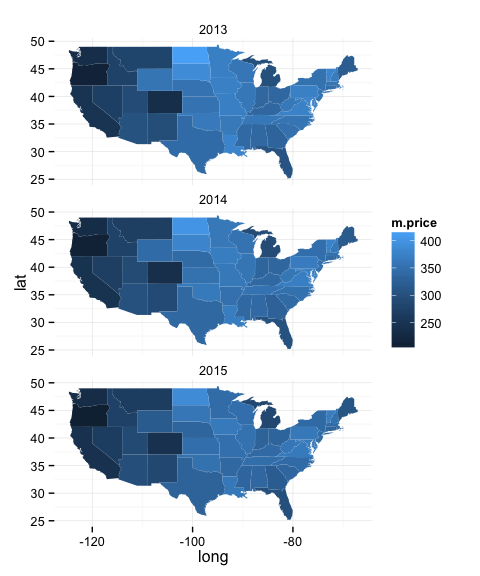

## `ggcounty`

The `ggcounty` package provides data at the U.S county level

```r
# devtools::install_github("hrbrmstr/ggcounty")
library("ggcounty")
data(population) # built-in US population by FIPS code data set
population$brk <- cut(population$count,
                      breaks=c(0, 100, 1000, 10000, 100000, 1000000, 10000000),
                      labels=c("0-99", "100-1K", "1K-10K", "10K-100K",
                               "100K-1M", "1M-10M"),
                      include.lowest=TRUE) # define appropriate (& nicely labeled) population breaks
us <- ggcounty.us()
gg <- us$g # start the plot with our base map
gg <- gg + geom_map(data=population, map=us$map,
                    aes(map_id=FIPS, fill=brk),
                    color="white", size=0.125) # add a new geom with our population (choropleth)
gg <- gg + scale_fill_manual(values=c("#ffffcc", "#c7e9b4", "#7fcdbb",
                                      "#41b6c4", "#2c7fb8", "#253494"),
                             name="Population")
```

## Output

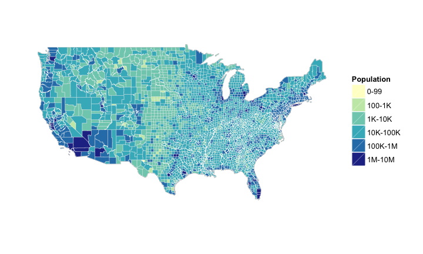

## `ggmap`

`ggmap` is a package that uses the `ggplot2` syntax as a template to create maps with image tiles taken from map servers such as Google and OpenStreetMap

Let's use some data on benches in Copenhagen

```r
df = read_csv("http://wfs-kbhkort.kk.dk/k101/ows?service=WFS&version=1.0.0&request=GetFeature&typeName=k101:baenk&outputFormat=csv&SRSNAME=EPSG:4326")
names(df)
```

```
##  [1] "FID"                "wkb_geometry"       "id"
##  [4] "vejkode"            "vejnavn"            "park_id"
##  [7] "bydel"              "distrikt"           "baenk_type"
## [10] "baenk_tilstand"     "baenk_placering"    "baenk_foto"
## [13] "baenk_driftsopgave" "baenk_fjernet"      "bemaerkning"
## [16] "reg_metode"         "reg_dato"           "rettet_dato"
```

## Data cleaning

We need to do quite some data cleaning

```r
library("dplyr")
library("stringr")
df = df %>%
  select(wkb_geometry, baenk_tilstand)

# cleaning
df$wkb_geometry = gsub("\\(|\\)", "", df$wkb_geometry)
df$wkb_geometry = str_extract(df$wkb_geometry, "[0-9].+")
x = str_split(df$wkb_geometry, pattern  = " ")
x = do.call(rbind.data.frame, x)
df = bind_cols(df, x)
names(df) = c("wbk_geometry", "baenk_tilstand", "lat", "lon")
df$lon = as.numeric(as.character(df$lon))
df$lat = as.numeric(as.character(df$lat))
```

## Plotting the data

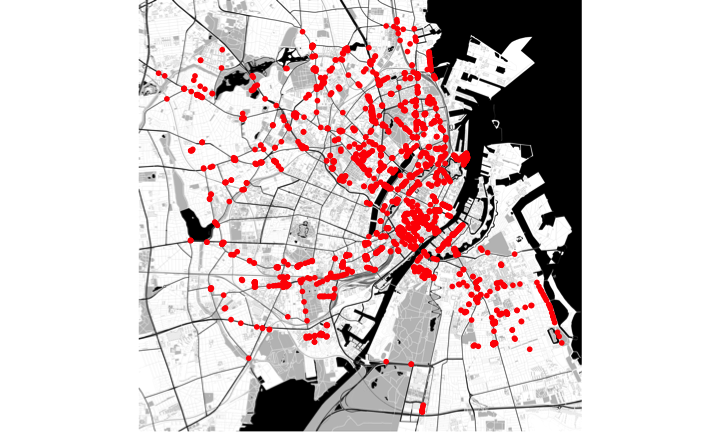

```r
library("ggmap")
qmplot(lat, lon, zoom = 15, data = df,
       maptype = "toner-background", color = I("red"))
```

## Plotting the data

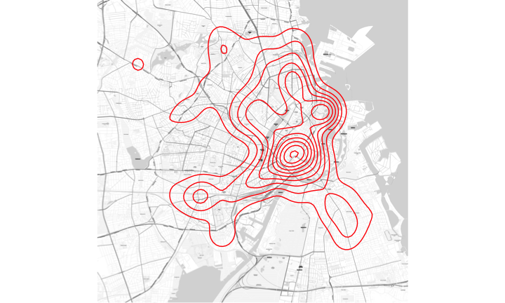

```r
qmplot(lat, lon, zoom = 15, data = df,
       maptype = "toner-lite", geom = "density2d", color = I("red"))
```

## `mapDK`

A package for making maps of Denmark at different levels of aggregation

### Functions

The package currently only has two functions:

- `mapDK` - makes the map
- `getID` - prints keys in case you run into merge problems

## getID

only accepts one argument: `detail`

```r
library(mapDK)
args(getID)
```

```
## function (detail = "municipal")
## NULL
```

```r
getID(detail = "municipal")[1:10]
```

```
##  [1] "aabenraa"    "aalborg"     "aeroe"       "albertslund" "alleroed"
##  [6] "aarhus"      "assens"      "ballerup"    "billund"     "bornholm"
```

```r
getID(detail = "region")
```

```
## [1] "hovedstaden" "midtjylland" "nordjylland" "sjaelland"   "syddanmark"
```

## mapDK

`mapDK` takes the following arguments

```r
args(mapDK)
```

```
## function (values = NULL, id = NULL, data, detail = "municipal",
##     show_missing = TRUE, sub = NULL, guide.label = NULL, map.title = NULL)
## NULL
```

- For basic maps you really only need `detail`, `sub` and `map.title`
- If you want to do choropleth maps you need to specify
  - `data`: A data frame of values and ids
  - `values`, `id`: String variables specifying names of value and id columns in the dataset
- returns a `ggplot2` object you can modify if you like

## Example I

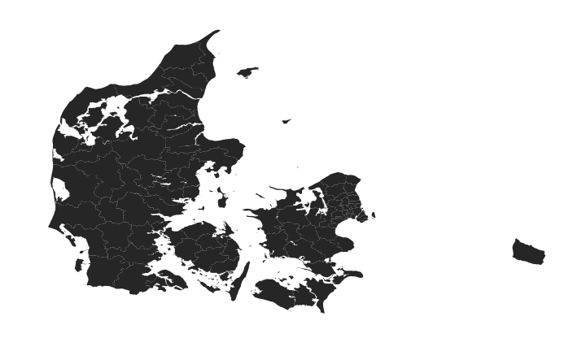

```r
mapDK()
```

## Example II

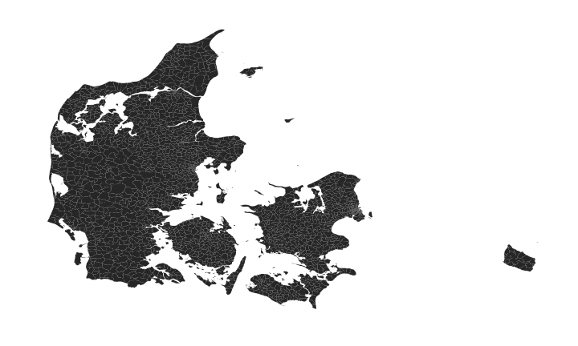

```r
mapDK(detail = "parish")
```

## Example III

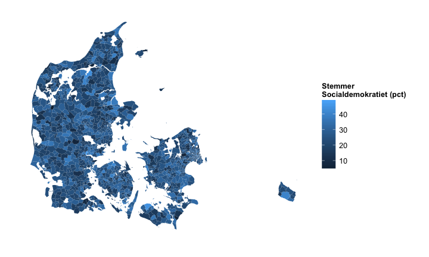

```r
mapDK(values = "stemmer", id = "id",
  data = subset(votes, navn == "socialdemokratiet"),
  detail = "polling", show_missing = FALSE,
  guide.label = "Stemmer \nSocialdemokratiet (pct)")
```

## Example IV

Putting it all togother…

```r
library("mapproj")
library("ggmap")
df = mapDK::polling
df.votes = mapDK::votes
df = df %>% filter(KommuneNav == "koebenhavn")
df.t = left_join(df, df.votes)
cph.map = ggmap(get_map(location = c(12.57, 55.68),
                       source = "stamen",
                       maptype = "toner", crop = TRUE,
                       zoom = 13))
p = cph.map +
  geom_polygon(data = subset(df.t, navn == "socialdemokratiet"),
                       aes(x = long, y = lat,
                           group = group, fill = stemmer),
                       alpha = .75)
```

## Output

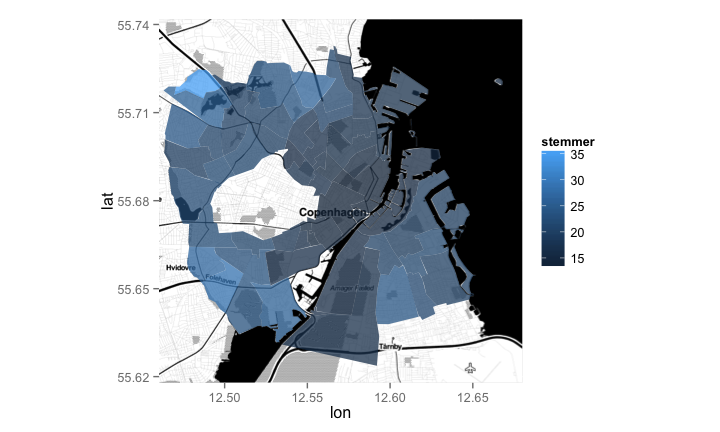

## Exercises

## Exercise 1

For this exercise we will work with data on GDP per capita at the country level. You can download the data using the `WDI` package as shown below

```r
# install.packages("WDI")
library("WDI")
library("dplyr")

df = WDI(indicator = "NY.GDP.PCAP.KN" ,
         start = 2010, end = 2010, extra = F)
df = df %>% filter(!is.na(NY.GDP.PCAP.KN))
```

**Question 1**: use the `map` package and the GDP data to make a world map of GDP per capita.

**Question 2**: install the package `countrycode` and use the `countrycode` function to add a region indicator to the dataset. Create a world map faceted by your region indicator.

## Exercise 2

In this exercise you will work with data on votes for the Danish general election from 2011. You can read the data using the following piece of code

```r
df = mapDK::votes
```

**Question 1**: use the `mapDK` package to make a map of votes (in pct) for the Conservative Party ("detkonservativefolkeparti") at the polling place level.

**Question 2**: read up on the documentation for the `dplyr` package to aggregate the data into votes (in pct) for the Conservatives at the municipal level. Plot the data using `mapDK`

**Question 3**: Repeat question 2 but only for the municipalities "Aarhus" and "Koebenhavn".

## Exercise 3

For this exercise we will work with Facebook data from the Danish parliamentary election 2015 kindly provided by [56 north](http://www.56n.dk/).

Load the data by running

```r
library(readr)
df = read_csv("https://raw.githubusercontent.com/sebastianbarfort/sds/master/data/FV15_data.csv")
```

**Question 1**: Use the `dplyr` package to aggregate the number of likes by party and "storkreds"

**Question 2**: Plot the data (do you need to facet?) on a map using the `mapDK` package.

**Question 3**: Use the `dplyr` package to sort the dataset according to the number of likes. Which candidate in the data is most popular? Create a dataset with only the most popular candidate by "storkreds".